# Regression Help Sheet

**Regression** is a tool that allows you to estimate a relationship between a single, interval-level dependent variable and one or more nominal-level, ordinal-level, and/or interval-level independent variables. Regression estimates (beta-hats) tell us the effect of a one-unit change in the independent variable on the dependent variable.

Let’s look at an example in R. First let’s load in the data:

```r
#Reading in the data
correlates2010 <- read.csv("correlates2010.csv")
```

For this first example, I’m going to examine the relationship between the proportion of Democrats in the state House chamber (the lower chamber in the state legislature) with the proportion of the population in that state that is nonwhite. The data are from 2010, and there is one observation for each state (except Nebraska which has a nonpartisan state legislature). To get an idea of what our regression might tell us, let’s look at a plot of both variables.

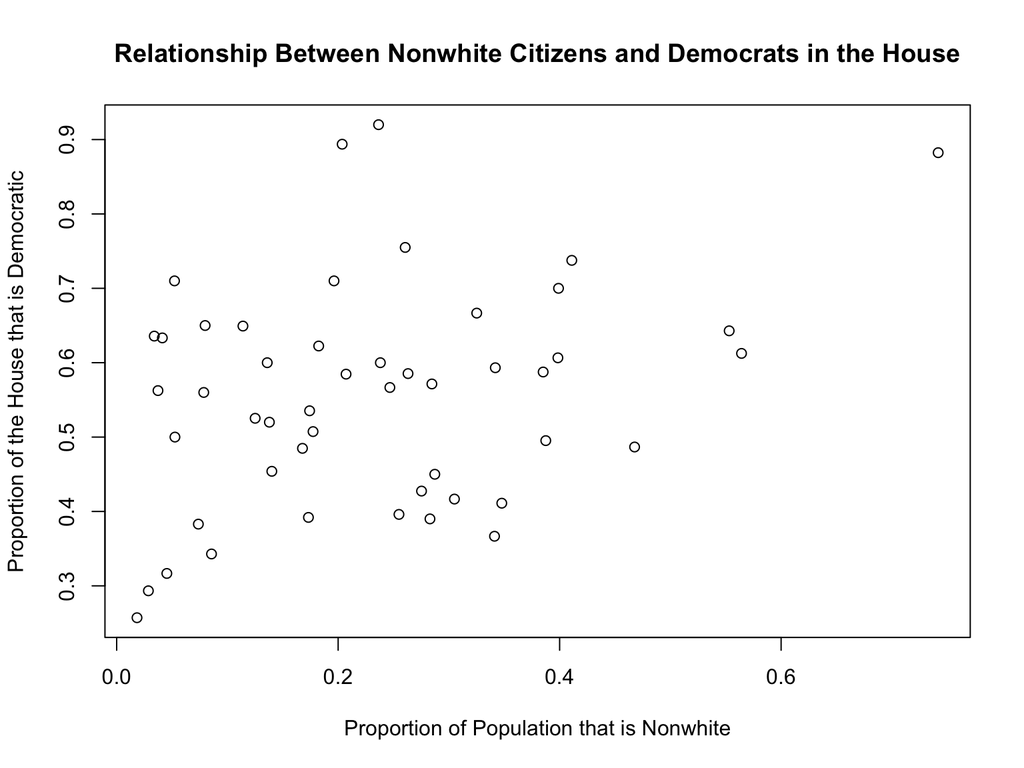

```r
#Plotting prop. Democrats and prop. nonwhite
plot(x = correlates2010$nonwhite, y = correlates2010$hs_dem_prop_all,
     main = "Relationship Between Nonwhite Citizens and Democrats in the House",
     xlab = "Proportion of Population that is Nonwhite",
     ylab = "Proportion of the House that is Democratic")
```

We already have some good evidence that there is a positive relationship between these variables. As though that as the proportion of a population that is nonwhite increases, so too does the proportion of the House that is Democratic.

## Running a Regression

Now that we think there might be evidence of a relationship, let’s put that to the test by running a regression. Running a regression in R is really quite simple! The function to run a regression is `lm()`. This stands for “linear model.” The function requires you to specify the relationship between your independent and dependent variables, separated by a tilde. The dependent variable goes first: *lm(y~x, data)*. Unlike the `t.test` commands and other commands that we have learned, the `lm()` command is smart: if you just provide the name of your dataset (here, “data”) to the command, you don’t need to use $ to indicate the dataset and variable names.

Here is an example of a regression with the variable used in the plot above (notice I don’t need correlates2010$ before the variables, because I’m using the *data* argument to tell R where the data is coming from):

```r
#Running univariate regression
regression1 <- lm(hs_dem_prop_all ~ nonwhite, data = correlates2010)
summary(regression1)
```

```
##
## Call:
## lm(formula = hs_dem_prop_all ~ nonwhite, data = correlates2010)
##
## Residuals:
##      Min       1Q   Median       3Q      Max
## -0.23230 -0.12345  0.00033  0.08315  0.36367
##
## Coefficients:
##             Estimate Std. Error t value Pr(>|t|)
## (Intercept)  0.48381    0.03652  13.249   <2e-16 ***
## nonwhite     0.30668    0.13067   2.347   0.0232 *
## ---
## Signif. codes:  0 '***' 0.001 '**' 0.01 '*' 0.05 '.' 0.1 ' ' 1
##
## Residual standard error: 0.1427 on 47 degrees of freedom
##   (1 observation deleted due to missingness)
## Multiple R-squared:  0.1049, Adjusted R-squared:  0.08586
## F-statistic: 5.509 on 1 and 47 DF,  p-value: 0.02319
```

Once you assign the regression a name (as I did in the above example with *regression1*), use the `summary()` function to examine the results of the regression. R gives us a lot of information with this summary! Let’s start with the information it gives us under *Estimate* column. These are the estimated beta-hats and the alpha-hat. If we look at the variable *nonwhite* and examine the first number in its row, we see 0.30668. In other words, this is the amount that our dependent variable (*hs_dem_prop_all*) changes as our independent variable (*nonwhite*) increases by one unit.

So is this result statistically significant? R calculates the t-statistic (the *t value* column: calculated by dividing the estimate by its standard error) and the correct p-value (the *Pr(>|t|)* column). If a result is statistically significant at p<.05, R will put an asterisk next to the p-value, as you see next to the p-value for nonwhite in this table. You can see what other numbers of asteriks mean with key right below the coefficient table. Generally, more asterisks mean that the relationship is statistically significant at an even more stringent p-value threshold.

## Adding a Regression Line to a Plot

Now that we have our regression done, we may want to visualize this linear relationship on our old plot. The easy way to do this is through the use of a regression line! To add a regression line to our plot, we employ the use of the *abline()* function. This takes one main argument: the regression formula. In the example below I also add the *col* argument to make the line stand out more by changing the color of the line. Also note that this function must come after the plot function (and after you’ve created your regression formula, of course!).

Here it is:

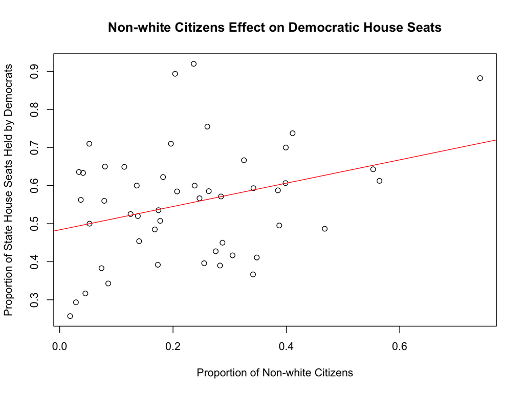

```r
#Plotting relationship between variables with regression line
plot(x = correlates2010$nonwhite, y = correlates2010$hs_dem_prop_all,
     main = "Non-white Citizens Effect on Democratic House Seats",
     xlab = "Proportion of Non-white Citizens",
     ylab = "Proportion of State House Seats Held by Democrats")

abline(regression1, col = "red")
```

The red line on this plot is the regression line we have estimated from these data.

## Creating Predicted Values

Predicted values (y-hats) are expected values of the dependent variable given our model’s estimates for alpha-hat and beta-hat. For example, let’s examine the predicted proportion of Democratic house seats as the proportion of the state population that is nonwhite varies from 0 to 1.

Next, we use the `predict()` function to calculate our y-hats. This function takes three main arguments: the estimated regression, the new values (our sequence of values), and the “type” (which in this case is “response”: this means that we want our predicted values to be on the same scale as our response (dependent) variable). In other words, this formula is doing is predicting a response value (*y-hat*) for every iteration of a new value of *x* and placing it in *prediction1*. The predict function provides the answer you would get if you calculated the y-hat by hand: alpha-hat + beta-hat*x.

Finally, we can plot our sequence of x values against the y-hats so we can visualize this relationship. **NOTE:** It is very important that we name our variables the same exact way that we do in our regression (i.e. spell nonwhite the same way in our new dataframe as we did in our regression) otherwise the `predict()` function will not run.

Here it is in practice:

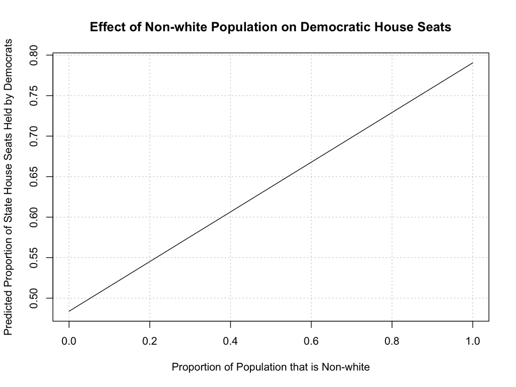

```r
#Making new dataframe of simulated values
new.data = data.frame(nonwhite = seq(0.00, 1.00, 0.10))

#Predicting dem house proportion beta values (x's)
new.data$prediction1 <- predict(regression1, new.data, type = "response")

#Plotting predictions vs simulated values
plot(x = new.data$nonwhite, y = new.data$prediction1, type = "l",
     main = "Effect of Non-white Population on Democratic House Seats",
     xlab = "Proportion of Population that is Non-white",
     ylab = "Predicted Proportion of State House Seats Held by Democrats",
     panel.first = grid())
```

The plot above makes it very easy to visualize the linear relationship between these variables! Looking at this, we can see that a proportion of 0.6 for the population that is nonwhite suggests a proportion of 0.67 house seats held by Democrats. (Also note that the `panel.first = grid()` argument simply adds a grid to this graph!)

## Running a Multivariate Regression

We can also use regression to estimate the relationship between an interval-level dependent variable and multiple independent variables. Perhaps in our last example the poverty rate helps to explain the proportion of state houses that are Democratic? Or even the ideology of the citizens?

To add more than one independent variable to our regression equation, we use the “+” symbol. The rest of the equation looks exactly the same!

Here is an example using three predictor variables:

```r
#Running a multivariate regression
regression2 <- lm(hs_dem_prop_all ~ nonwhite + ideo + povrate, data = correlates2010)
summary(regression2)
```

```
##
## Call:
## lm(formula = hs_dem_prop_all ~ nonwhite + ideo + povrate, data = correlates2010)
##
## Residuals:
##       Min        1Q    Median        3Q       Max
## -0.216551 -0.083199 -0.001512  0.080627  0.243794
##
## Coefficients:
##             Estimate Std. Error t value Pr(>|t|)
## (Intercept) 0.582963   0.074630   7.811  6.5e-10 ***
## nonwhite    0.176738   0.131280   1.346 0.184959
## ideo        0.666973   0.162988   4.092 0.000175 ***
## povrate     0.005043   0.006753   0.747 0.459116
## ---
## Signif. codes:  0 '***' 0.001 '**' 0.01 '*' 0.05 '.' 0.1 ' ' 1
##
## Residual standard error: 0.1207 on 45 degrees of freedom
##   (1 observation deleted due to missingness)
## Multiple R-squared:  0.3864, Adjusted R-squared:  0.3455
## F-statistic: 9.447 on 3 and 45 DF,  p-value: 5.889e-05
```

Now when we examine the results of the regression, we see something quite peculiar! The effect that the proportion of the population that is nonwhite had on the proportion of state house seats that are Democratic is no longer significant! The only statistically significant variable in this regression model is the ideology of the citizenry. This tells us that the higher the ideology score (more liberal), the greater the proportion of the state houses that are Democratic.

## Coefficient Plots

Another way to help visualize coefficients in R is through the use of the `coefplot()` function. This function simply plots a regression’s coefficients and 2 of its standard deviations. In other words, it’s plotting a confidence interval for each of the coefficients.

This function takes one main argument, the regression. In the example below we add two more arguments to clear up the graph. We add `xlim` to make sure that all the confidence intervals fit on the plot, and `intercept = TRUE` so that the intercept also appeared on the plot. There are two notes on this code. First, if you’ve never used the `coefplot()` function before, you may need to install it on you computer using `install.packages("arm")` within R. Second the \n between “Poverty” and “Rate” inserts a line break. You can use this whenever you need a line break in a plot.

Here is that example using the second regression example:

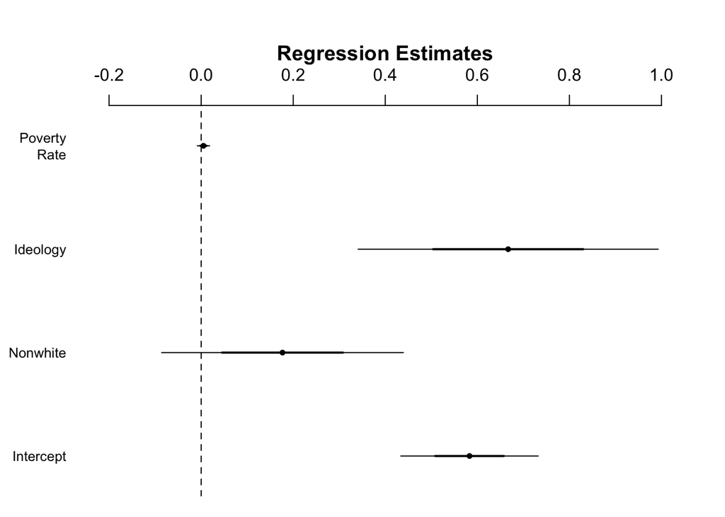

```r
#Making a coefficient plot with the second regression example
library(arm)
coefplot(regression2,
         xlim = c(-0.2,1),
         intercept = TRUE, varnames = c("Intercept","Nonwhite", "Ideology","Poverty\nRate"))
```

Each row is a different independent variable with the lines representing the first and second standard deviations for each one. The thicker line contains all values within 1 SD of the coefficient (68% confidence interval), and the thinner line contains all values within 2 SD of the coefficient (95% confidence interval). This gives us a better sense of the variability in each coefficient across this model. We can see whether the confidence interval crosses the vertical 0 line as a test of statistical significance.

## Predicting Values with Multivariate Regressions

Predicting y-hats for multivariate regressions is done nearly the exact same way as we have done before. The first step is to create a sequence of simulated values using `seq()` for the variable we want to examine. In the following example we’ll examine the ideology of the citizenry (*ideo*). Next, we’ll want to hold the other variables constant in this dataset by setting them to their mean, this allows us to just focus on ideology (the same could be done for povrate or nonwhite if we switched the variables around). Finally, we create the beta values based of our new dataset, plug them into the *prediction2* variable, and plot them!

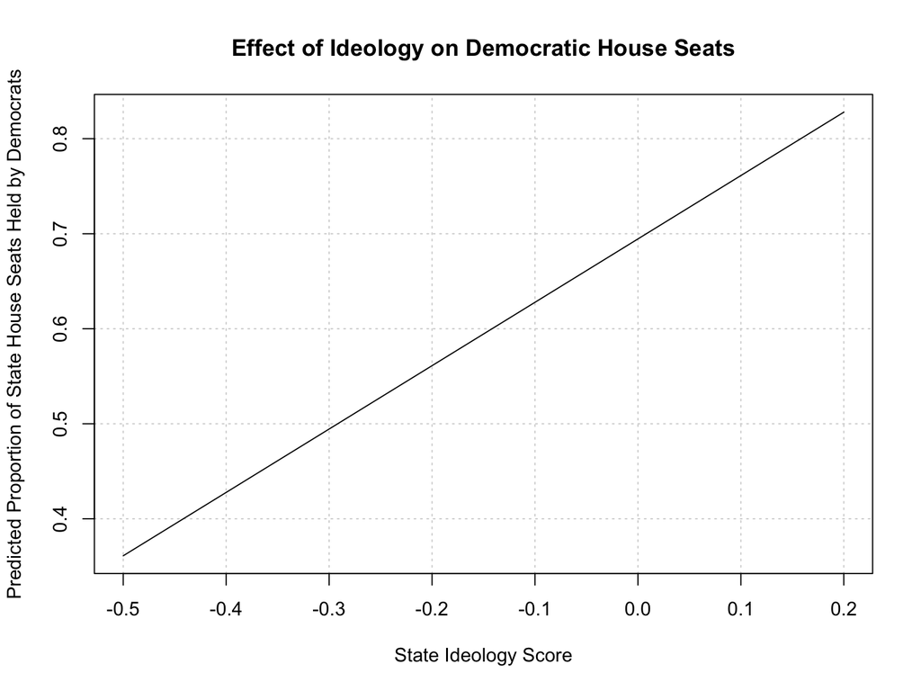

```r
#Making new dataframe
new.data2 = data.frame(ideo = seq(-0.5, 0.2, 0.10),
                      nonwhite = mean(correlates2010$nonwhite, na.rm = TRUE),
                      povrate = mean(correlates2010$povrate, na.rm = TRUE))

#Predicting dem house seat proportion
new.data2$prediction2 <- predict(regression2, new.data2, type = "response")

#Plotting prediction
plot(x = new.data2$ideo, y = new.data2$prediction2, type = "l",
     main = "Effect of Ideology on Democratic House Seats",
     xlab = "State Ideology Score",
     ylab = "Predicted Proportion of State House Seats Held by Democrats",
     panel.first = grid())
```

This plot helps us to see that as the state ideology score increases (holding all else equal), so too does the proportion of the state house seats held by Democrats.

## Interaction Terms

There will be other times in our research where we might think that the effect of one variable varies based on the value another variable takes. We can test this theory by adding an interaction term to our regression equation. For example, we know that politics in the U.S. South differs from politics in the rest of the country, so let’s test the hypothesis that the effect of citizen ideology on partisan representation in the state legislature varies based on whether or not the state is a southern state. To test this in our regression we’ll simply add one more term that multiplies the variables together.

This is what our new regression would look like:

```r
#Running a regression with an interaction term
library(car)
correlates2010$south <- recode(correlates2010$region_census,"1=1;else=0")
regression_interaction <- lm(hs_dem_prop_all ~ ideo + south + ideo*south, data = correlates2010)
summary(regression_interaction)
```

```
##
## Call:
## lm(formula = hs_dem_prop_all ~ ideo + south + ideo * south, data = correlates2010)
##
## Residuals:
##      Min       1Q   Median       3Q      Max
## -0.22510 -0.06691 -0.01043  0.08916  0.21357
##
## Coefficients:
##             Estimate Std. Error t value Pr(>|t|)
## (Intercept)   0.7177     0.0345  20.806  < 2e-16 ***
## ideo          0.9146     0.1645   5.561 1.39e-06 ***
## south        -0.1161     0.1004  -1.157   0.2534
## ideo:south   -0.6977     0.3436  -2.031   0.0482 *
## ---
## Signif. codes:  0 '***' 0.001 '**' 0.01 '*' 0.05 '.' 0.1 ' ' 1
##
## Residual standard error: 0.1178 on 45 degrees of freedom
##   (1 observation deleted due to missingness)
## Multiple R-squared:  0.4154, Adjusted R-squared:  0.3764
## F-statistic: 10.66 on 3 and 45 DF,  p-value: 2.049e-05
```

It appears that our interaction term is statistically significant, as shown by the coefficient for `ideo:south` in our output.

## Plotting Interactions

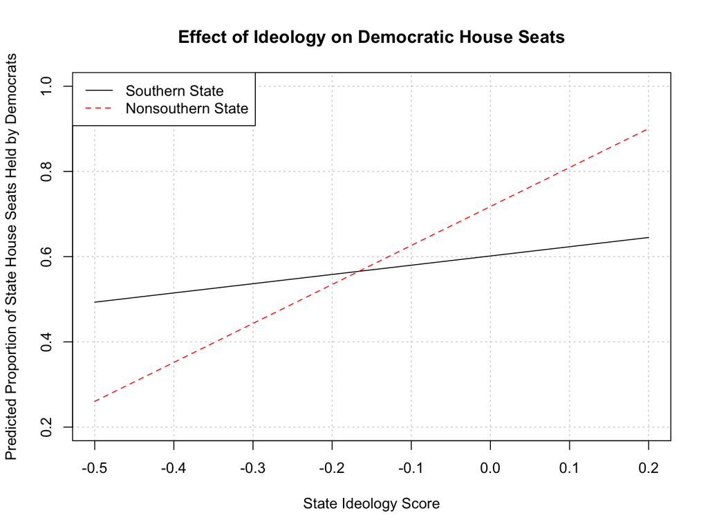

```r
#Making new dataframe
south = data.frame(ideo = seq(-0.5, 0.2, 0.10),
                      south=1)
nonsouth = data.frame(ideo = seq(-0.5, 0.2, 0.10),
                      south=0)

#Predicting dem house seat proportion
south$prediction <- predict(regression_interaction, south, type = "response")
nonsouth$prediction <- predict(regression_interaction, nonsouth, type = "response")

#Plotting prediction
plot(x = south$ideo, y = south$prediction, type = "l",
     main = "Effect of Ideology on Democratic House Seats",
     xlab = "State Ideology Score",
     ylab = "Predicted Proportion of State House Seats Held by Democrats",
     panel.first = grid(), ylim=c(.2,1))
lines(x = nonsouth$ideo, y = nonsouth$prediction, col="red", lty=2)
legend("topleft", c("Southern State","Nonsouthern State"), lty=c(1,2),
       col=c("black","red"))
```

In this plot, the regression line for states in the south is shown in black and the regression line for nonsouthern states is shown in red. We see that the slope of the red line is much steeper than the slope of the black line.

We can also plot the *marginal effect* of being a southern state across the range of values ideology can take. We do this by using the formula for the marginal effect, which is the coefficient of the variable we are interested in plus the coefficient of the interaction term times the other variable to the interaction (here, ideology). So, in our example, the formula is Beta_South + Beta_Interaction * Ideology. Note that when creating `effect_line` below, I use the coefficients from the model (regression_interaction):

```r
#Making new dataframe
regression_interaction
```

```
##
## Call:
## lm(formula = hs_dem_prop_all ~ ideo + south + ideo * south, data = correlates2010)
##
## Coefficients:
## (Intercept)         ideo        south   ideo:south
##      0.7177       0.9146      -0.1161      -0.6977
```

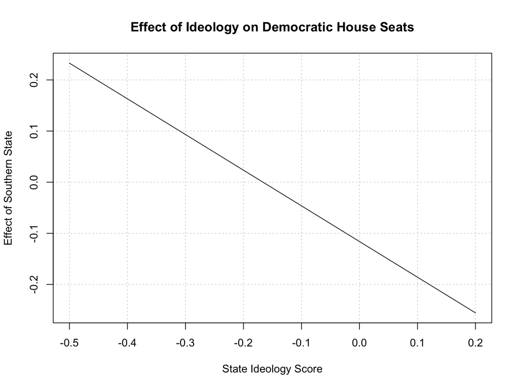

```r
effect_line = -0.1161 -0.6977*south$ideo


#Plotting prediction
plot(x = south$ideo, y = effect_line, type = "l",
     main = "Effect of Ideology on Democratic House Seats",
     xlab = "State Ideology Score",
     ylab = "Effect of Southern State",
     panel.first = grid())
```

## Running a Regression with a Categorical Variable

Sometimes we may want to run a regression with a variable that is categorical, such as region of the country. Let’s see what happens when we run a regression with the proportion of state house seats that are Democratic with a variable coded 1-4 for the region (South=1, West=2, Midwest=3, Northeast=4):

```r
#Running a regression with a categorical variable
regression4 <- lm(hs_dem_prop_all ~ region_census, data = correlates2010)
summary(regression4)
```

```
##
## Call:
## lm(formula = hs_dem_prop_all ~ region_census, data = correlates2010)
##
## Residuals:
##      Min       1Q   Median       3Q      Max
## -0.28826 -0.09843 -0.01430  0.07705  0.33695
##
## Coefficients:
##               Estimate Std. Error t value Pr(>|t|)
## (Intercept)    0.47367    0.04744   9.985 3.37e-13 ***
## region_census  0.03586    0.01883   1.905    0.063 .
## ---
## Signif. codes:  0 '***' 0.001 '**' 0.01 '*' 0.05 '.' 0.1 ' ' 1
##
## Residual standard error: 0.1453 on 47 degrees of freedom
##   (1 observation deleted due to missingness)
## Multiple R-squared:  0.07165,    Adjusted R-squared:  0.0519
## F-statistic: 3.627 on 1 and 47 DF,  p-value: 0.06296
```

R gave us an output but it doesn’t make much sense. Think about it: this is essentially saying that for every one-unit increase in census region, there is a 0.03586 increase in the proportion of state house seats that are Democratic. This doesn’t make sense because census region is an nominal variable where the distance between the numbers has no meaning. The value of “4” isn’t higher than the value of “1” in a numeric sense: they represent different regions of the country.

To fix this problem, we’ll use the `as.factor()` function around the census region variable to tell R that we want it to read the values within the variable as factors, not numbers with intrinsic meaning. When this happens, R will use the first (in numeric or alphabetical order) value of the variable as the baseline category and will automatically create dichotomous variables coded 0 if the observation does not fall into that category and 1 if the observation does fall in that category.

Here is an example of that:

```r
#Running a regression with a categorical variable
regression3 <- lm(hs_dem_prop_all ~ as.factor(region_census), data = correlates2010)
summary(regression3)
```

```
##
## Call:
## lm(formula = hs_dem_prop_all ~ as.factor(region_census), data = correlates2010)
##
## Residuals:
##      Min       1Q   Median       3Q      Max
## -0.26941 -0.10989  0.01501  0.08823  0.35580
##
## Coefficients:
##                           Estimate Std. Error t value Pr(>|t|)
## (Intercept)                0.53722    0.03468  15.491   <2e-16 ***
## as.factor(region_census)2 -0.01067    0.05180  -0.206   0.8378
## as.factor(region_census)3 -0.03223    0.05433  -0.593   0.5560
## as.factor(region_census)4  0.15113    0.05780   2.615   0.0121 *
## ---
## Signif. codes:  0 '***' 0.001 '**' 0.01 '*' 0.05 '.' 0.1 ' ' 1
##
## Residual standard error: 0.1387 on 45 degrees of freedom
##   (1 observation deleted due to missingness)
## Multiple R-squared:   0.19,  Adjusted R-squared:  0.136
## F-statistic: 3.519 on 3 and 45 DF,  p-value: 0.02244
```

This fixed the problem! We know have a coefficient for each census region (region 1–the south–is dropped by R and used as the baseline). From this, we can draw the conclusion that only the 4th region (the Northeast) is statistically significant in this model. Because the south is the baseline region, this means there is a statistically significant difference between the proportion of Democrats in the state house in the northeast (region==4) and the proportion of Democrats in the state house in the south.

## Predicting Values for Categorical Variable

Predicating values for categorical variables is once again very similar to how it was done in the previous examples. For the dataframe we’ll use the census values (1-4) as our simulated values and calculate y-hats. Since this is a categorical variable, we’ll use the *barplot()* function to plot the predicted values instead of the *plot()* values.

Here is an example of that:

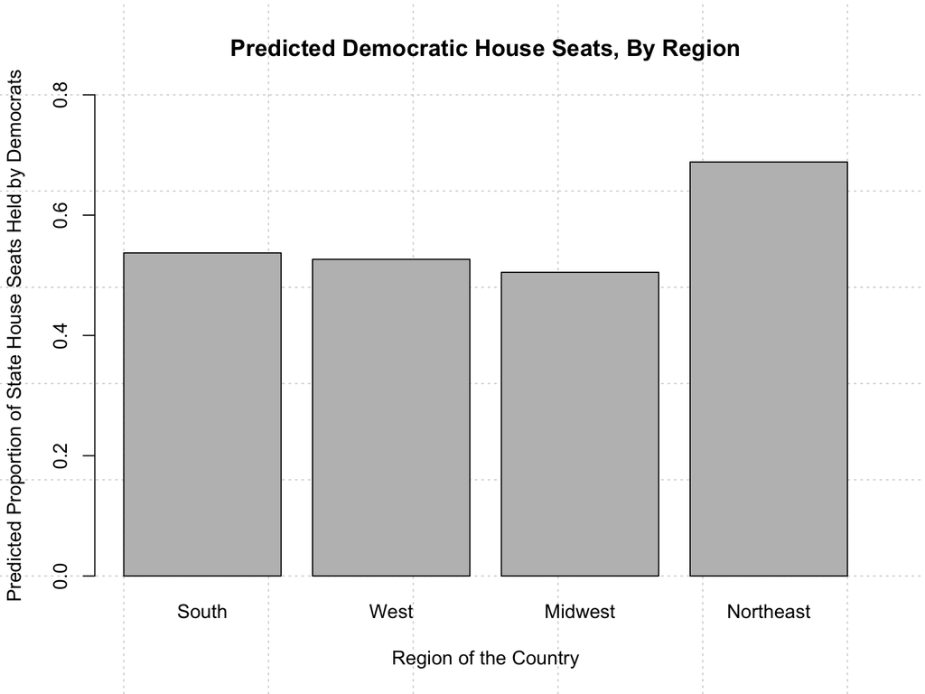

```r
#Making new dataframe for region
new.data3 = data.frame(region_census = c(1, 2, 3, 4))

#Predicting dem house seat proportion
new.data3$prediction3 <- predict(regression3, new.data3, type = "response")

#Plotting predicion
barplot(new.data3$prediction3,
     main = "Predicted Democratic House Seats, By Region",
     xlab = "Region of the Country",
     ylab = "Predicted Proportion of State House Seats Held by Democrats",
     panel.first = grid(),
     ylim = c(0,.8),
     names.arg = c("South", "West", "Midwest", "Northeast"))
```

From this we can see that the Northeast has the biggest effect on the proportion of state house seats that are Democratic!

Finally, let’s add another variable, ideology, to the model and plot separate regression lines for each region across the range of ideology. For convenience sake, I have included the data.frame in the prediction command. See that the four commands are the same with the exception of the changed value for region_census.

```r
#Running a regression with a categorical variable
regression5 <- lm(hs_dem_prop_all ~ ideo + as.factor(region_census), data = correlates2010)
summary(regression3)
```

```
##
## Call:
## lm(formula = hs_dem_prop_all ~ as.factor(region_census), data = correlates2010)
##
## Residuals:
##      Min       1Q   Median       3Q      Max
## -0.26941 -0.10989  0.01501  0.08823  0.35580
##
## Coefficients:
##                           Estimate Std. Error t value Pr(>|t|)
## (Intercept)                0.53722    0.03468  15.491   <2e-16 ***
## as.factor(region_census)2 -0.01067    0.05180  -0.206   0.8378
## as.factor(region_census)3 -0.03223    0.05433  -0.593   0.5560
## as.factor(region_census)4  0.15113    0.05780   2.615   0.0121 *
## ---
## Signif. codes:  0 '***' 0.001 '**' 0.01 '*' 0.05 '.' 0.1 ' ' 1
##
## Residual standard error: 0.1387 on 45 degrees of freedom
##   (1 observation deleted due to missingness)
## Multiple R-squared:   0.19,  Adjusted R-squared:  0.136
## F-statistic: 3.519 on 3 and 45 DF,  p-value: 0.02244
```

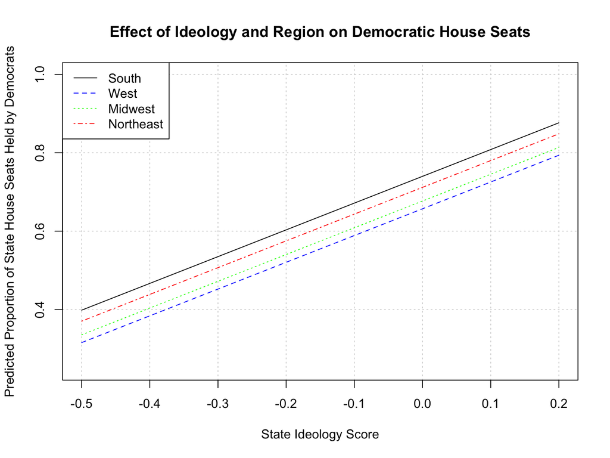

```r
#Predicting dem house seat proportion
predict_south <- predict(regression5, data.frame(region_census=1,ideo = seq(-0.5, 0.2, 0.10)), type = "response")
predict_west <- predict(regression5, data.frame(region_census=2,ideo = seq(-0.5, 0.2, 0.10)), type = "response")
predict_midwest <- predict(regression5, data.frame(region_census=3,ideo = seq(-0.5, 0.2, 0.10)), type = "response")
predict_northeast <- predict(regression5, data.frame(region_census=4,ideo = seq(-0.5, 0.2, 0.10)), type = "response")

#Plotting predicion
plot(x=seq(-0.5, 0.2, 0.10),y=predict_south,type="l",
     main = "Effect of Ideology and Region on Democratic House Seats",
     xlab = "State Ideology Score",
     ylab = "Predicted Proportion of State House Seats Held by Democrats",
     panel.first = grid(),
     ylim = c(.25,1))
lines(x=seq(-0.5, 0.2, 0.10),y=predict_west,lty=2,col="blue")
lines(x=seq(-0.5, 0.2, 0.10),y=predict_midwest,lty=3,col="green")
lines(x=seq(-0.5, 0.2, 0.10),y=predict_northeast,lty=4,col="red")
legend("topleft", c("South","West","Midwest","Northeast"), lty=c(1,2,3,4),
       col=c("black","blue","green","red"))
```

## A Better Way to View Regressions

Finally, when presenting results we’ll always want to make our findings clear. Anyone reading our results should not have to read our paper/presentation in order to find out the results of our regression. To make a pretty-looking regression table, we’ll use the package `stargazer`. (This package may already be installed on your machine but if it isn’t use `install.packages(stargazer)` to install the package).

Next, we’ll want to call this library with `library(stargazer)` so that R knows where to find this function. To create a nicely formatted regression table, we use the function `stargazer()`. For the example below I’m using the regression from the second example (regression2)! The arguments for this function are as follows: the regression model, the type of output (`type="text"`), the label of the dependent variable (`dep.var.labels`), and the labels for the coefficients (`covariate.labels`).

Here is how it looks all put together:

```r
#Calling the stargazer library
library(stargazer)
#Running the stargazer function
stargazer(regression2,
          type = "text",
          dep.var.labels = "Democratic Seats",
          covariate.labels = c("Proportion Nonwhite", "Ideology Score", "Poverty Rate"))
```

```
##
## ===============================================
##                         Dependent variable:
##                     ---------------------------
##                          Democratic Seats
## -----------------------------------------------
## Proportion Nonwhite            0.177
##                               (0.131)
##
## Ideology Score               0.667***
##                               (0.163)
##
## Poverty Rate                   0.005
##                               (0.007)
##
## Constant                     0.583***
##                               (0.075)
##
## -----------------------------------------------
## Observations                    49
## R2                             0.386
## Adjusted R2                    0.346
## Residual Std. Error       0.121 (df = 45)
## F Statistic            9.447*** (df = 3; 45)
## ===============================================
## Note:               *p<0.1; **p<0.05; ***p<0.01
```

We finally have a nice and readable regression table! The important aspects of this table to note are the following: the coefficients are given in each row with asteriks denoting statistical significance, and their standard errors are presented beneath them. From this table we can conclude that as the ideology measure increases, so too does the proportion of state house seats that are Democratic. This is significant at the alpha = 0.01 level. This is how almost all regression tables look in peer-reviewed research papers, and you can make them with a single line of code!

Helpsheet made by Jacob Ryan.